# LSTAT2340 - Analyse de données transcriptomique : données RNA-SEQ générées avec une plateforme NGS de la marque Illumina

Jerome Ambroise - UCL - IREC - CTMA

février 19, 2024,11:28

Dans le document, ci dessous, nous allons analyser des données de transcriptomique (RNA-SEQ) générées avec une plateforme NGS Illumina.

Les données proviennent du prolongement de l’étude “MicroArray Quality Control (MAQC) project” appelée SEQC. Dans ce document, nous analysons 5 échantillons A (A1, A2, A3, A4 et A5) et 5 échantillons B (B1, B2, B3, B4 et B5) et l’objectif est d’identifier les gènes qui sont modulés.

# 1 Chargement des packages et importation des données.

Nous commençons par charger le package edger. edger est un package bioconductor qui dispose d’un “user guide” très complet.

```r
library(edgeR)
library(org.Hs.eg.db)
library(gplots)
library(ggplot2)
```

Nous chargeons ensuite les données. On va créer une DGElist. Cette DGElist a besoin de 3 informations:

- la matrice de comptage
- les noms des gènes
- les groupes (phénotypes)

```r
rm(list=ls())
count_table <- read.table('data/ILM/ILM.txt')
head(count_table)
```

```
##    EntrezID Symbol A_1_L01_FlowCellA A_2_L01_FlowCellA A_3_L01_FlowCellA
## 3     29974   A1CF                21                33                26
## 6         2    A2M              2683              2212              2769
## 7    144568  A2ML1                 4                 1                 1
## 8         3  A2MP1                 1                 0                 2
## 9     53947 A4GALT                44                34                35
## 10    51146  A4GNT                 1                 0                 0
##    A_4_L01_FlowCellA A_5_L01_FlowCellA B_1_L01_FlowCellA B_2_L01_FlowCellA
## 3                 34                31                 0                 0
## 6               3344              2803               911               841
## 7                  2                 5                12                13
## 8                  3                 1                 1                 5
## 9                 38                36                34                31
## 10                 0                 0                 1                 0
##    B_3_L01_FlowCellA B_4_L01_FlowCellA B_5_L01_FlowCellB
## 3                  0                 0                 0
## 6                960               753               597
## 7                 12                 7                14
## 8                  5                 2                 6
## 9                 22                28                10
## 10                 0                 1                 1
```

```r
keytypes(org.Hs.eg.db)
```

```
##  [1] "ACCNUM"       "ALIAS"        "ENSEMBL"      "ENSEMBLPROT"  "ENSEMBLTRANS"
##  [6] "ENTREZID"     "ENZYME"       "EVIDENCE"     "EVIDENCEALL"  "GENENAME"
## [11] "GENETYPE"     "GO"           "GOALL"        "IPI"          "MAP"
## [16] "OMIM"         "ONTOLOGY"     "ONTOLOGYALL"  "PATH"         "PFAM"
## [21] "PMID"         "PROSITE"      "REFSEQ"       "SYMBOL"       "UCSCKG"
## [26] "UNIPROT"
```

```r
SYMBOL <- mapIds(org.Hs.eg.db, keys=as.character(count_table$EntrezID),keytype="ENTREZID", column="SYMBOL")
ENSEMBL <- mapIds(org.Hs.eg.db, keys=as.character(count_table$EntrezID),keytype="ENTREZID", column="ENSEMBL")
genes <- data.frame(count_table[,1:2],SYMBOL,ENSEMBL)
head(genes)
```

```
##    EntrezID Symbol SYMBOL         ENSEMBL
## 3     29974   A1CF   A1CF ENSG00000148584
## 6         2    A2M    A2M ENSG00000175899
## 7    144568  A2ML1  A2ML1 ENSG00000166535
## 8         3  A2MP1  A2MP1 ENSG00000256069
## 9     53947 A4GALT A4GALT ENSG00000128274
## 10    51146  A4GNT  A4GNT ENSG00000118017
```

```r
group <- c(rep('A',5),rep('B',5))
dge <- DGEList(counts=count_table[,-c(1,2)],group=group,genes =genes )
```

# 2 Filtre sur les gènes faiblement exprimés et normalisation des données

```r
dge
```

```
## An object of class "DGEList"
## $counts
##   A_1_L01_FlowCellA A_2_L01_FlowCellA A_3_L01_FlowCellA A_4_L01_FlowCellA
## 3                21                33                26                34
## 6              2683              2212              2769              3344
## 7                 4                 1                 1                 2
## 8                 1                 0                 2                 3
## 9                44                34                35                38
##   A_5_L01_FlowCellA B_1_L01_FlowCellA B_2_L01_FlowCellA B_3_L01_FlowCellA
## 3                31                 0                 0                 0
## 6              2803               911               841               960
## 7                 5                12                13                12
## 8                 1                 1                 5                 5
## 9                36                34                31                22
##   B_4_L01_FlowCellA B_5_L01_FlowCellB
## 3                 0                 0
## 6               753               597
## 7                 7                14
## 8                 2                 6
## 9                28                10
## 19788 more rows ...
##
## $samples
##                   group lib.size norm.factors
## A_1_L01_FlowCellA     A  3309045            1
## A_2_L01_FlowCellA     A  2768691            1
## A_3_L01_FlowCellA     A  3440870            1
## A_4_L01_FlowCellA     A  3938889            1
## A_5_L01_FlowCellA     A  3414075            1
## B_1_L01_FlowCellA     B  3968046            1
## B_2_L01_FlowCellA     B  3851746            1
## B_3_L01_FlowCellA     B  4166623            1
## B_4_L01_FlowCellA     B  3150904            1
## B_5_L01_FlowCellB     B  2573246            1
##
## $genes
##   EntrezID Symbol SYMBOL         ENSEMBL
## 3    29974   A1CF   A1CF ENSG00000148584
## 6        2    A2M    A2M ENSG00000175899
## 7   144568  A2ML1  A2ML1 ENSG00000166535
## 8        3  A2MP1  A2MP1 ENSG00000256069
## 9    53947 A4GALT A4GALT ENSG00000128274
## 19788 more rows ...
```

```r
keep <- rowSums(cpm(dge)>1) >= 3
table(keep)
```

```
## keep
## FALSE  TRUE
##  4814 14979
```

```r
dge <- dge[keep, , keep.lib.sizes=FALSE]
dge <- calcNormFactors(dge)
dge
```

```
## An object of class "DGEList"
## $counts
##   A_1_L01_FlowCellA A_2_L01_FlowCellA A_3_L01_FlowCellA A_4_L01_FlowCellA
## 3                21                33                26                34
## 6              2683              2212              2769              3344
## 7                 4                 1                 1                 2
## 8                 1                 0                 2                 3
## 9                44                34                35                38
##   A_5_L01_FlowCellA B_1_L01_FlowCellA B_2_L01_FlowCellA B_3_L01_FlowCellA
## 3                31                 0                 0                 0
## 6              2803               911               841               960
## 7                 5                12                13                12
## 8                 1                 1                 5                 5
## 9                36                34                31                22
##   B_4_L01_FlowCellA B_5_L01_FlowCellB
## 3                 0                 0
## 6               753               597
## 7                 7                14
## 8                 2                 6
## 9                28                10
## 14974 more rows ...
##
## $samples
##                   group lib.size norm.factors
## A_1_L01_FlowCellA     A  3307020    1.0964455
## A_2_L01_FlowCellA     A  2767017    1.1098730
## A_3_L01_FlowCellA     A  3438736    1.1003084
## A_4_L01_FlowCellA     A  3936541    1.0990998
## A_5_L01_FlowCellA     A  3411892    1.1052879
## B_1_L01_FlowCellA     B  3965843    0.9017036
## B_2_L01_FlowCellA     B  3849612    0.9044131
## B_3_L01_FlowCellA     B  4164321    0.9109723
## B_4_L01_FlowCellA     B  3149096    0.9105741
## B_5_L01_FlowCellB     B  2571756    0.9087858
##
## $genes
##   EntrezID Symbol SYMBOL         ENSEMBL
## 3    29974   A1CF   A1CF ENSG00000148584
## 6        2    A2M    A2M ENSG00000175899
## 7   144568  A2ML1  A2ML1 ENSG00000166535
## 8        3  A2MP1  A2MP1 ENSG00000256069
## 9    53947 A4GALT A4GALT ENSG00000128274
## 14974 more rows ...
```

# 3 Création des modèles statistiques pour détecter les gènes modulés

Pour rappel, le but est de comparer les niveaux d’expression de chacun des gènes entre les 5 échantillons ‘A’ et les 5 échantillons ‘B’. Nous commencçons par spécifier à R le design de notre expérience. Une fois que le modèle est construit, on spécifie le contraste pour lequel on veut obtenir les statistique (logfc, p-valeur, etc).

```r
group <- dge$sample$group
design <- model.matrix(~0+group)
design
```

```
##    groupA groupB
## 1       1      0
## 2       1      0
## 3       1      0
## 4       1      0
## 5       1      0
## 6       0      1
## 7       0      1
## 8       0      1
## 9       0      1
## 10      0      1
## attr(,"assign")
## [1] 1 1
## attr(,"contrasts")
## attr(,"contrasts")$group
## [1] "contr.treatment"
```

```r
dge <- estimateDisp(dge,design)

contrast <- "groupB-groupA"
contrasts <- as.data.frame(makeContrasts(contrasts = contrast, levels = design))

fit <- glmQLFit(dge,design)
qlf <- glmQLFTest(fit,contrast = contrasts)
```

# 4 5: Extraction des résultats

Dans l’exemple ci-dessous, l’ajustement de la p-valeur est réalisé avec la méthode ‘BH’ (Benjamini-Hochberg).

```r
topTags(qlf,n=15,adjust.method = 'BH')
```

```
## Coefficient:  -1*groupA 1*groupB
##       EntrezID  Symbol  SYMBOL         ENSEMBL      logFC    logCPM         F
## 13600     2670    GFAP    GFAP ENSG00000131095  11.382574 11.710161 20597.176
## 43464     6616  SNAP25  SNAP25 ENSG00000132639   9.722524 11.084129 14424.267
## 826        338    APOB    APOB ENSG00000084674  -9.964326  9.808057 12876.388
## 9871     23017   FAIM2   FAIM2 ENSG00000135472   9.374574  9.565950 11792.174
## 509        213     ALB     ALB ENSG00000163631 -10.121727  9.748575 11674.377
## 9901     11170 FAM107A FAM107A ENSG00000168309   9.180958  9.265015 11497.084
## 19397     3798   KIF5A   KIF5A ENSG00000155980   6.941855 10.172855 11424.554
## 25986     4155     MBP     MBP ENSG00000197971   6.830128 10.702507 11417.172
## 4608    222166 C7ORF41   MTURN ENSG00000180354   5.576489 10.151731 11154.647
## 28748    65009   NDRG4   NDRG4 ENSG00000103034   7.306582  9.711772 10731.147
## 33214     5354    PLP1    PLP1 ENSG00000123560   6.412627  9.693450 10062.129
## 12175     2335     FN1     FN1 ENSG00000115414  -4.461205 11.108075  9737.104
## 48370     6855     SYP     SYP ENSG00000102003   6.958499  8.905915  9704.483
```

[output cut: 18 more lines]

# 5 6: Quelques graphiques

## 5.1 6.1 Heatmap

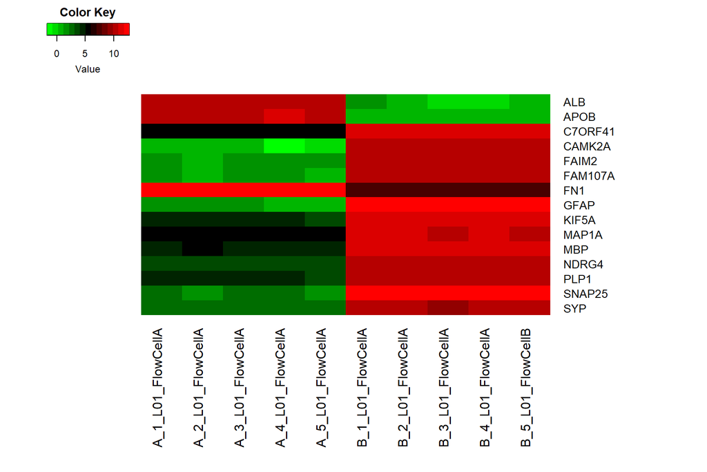

```r
logcpm <- cpm(dge,normalized.lib.sizes=TRUE, log=T, prior.count=0.25)
rownames(logcpm) <- dge$genes$Symbol

logcpm_selected <- logcpm[is.element(rownames(logcpm),data.frame(topTags(qlf,n=15))$Symbol),]

heatmap.2(as.matrix(logcpm_selected),col='greenred',trace='none',dendrogram='none',margins = c(12,12),symbreaks=F,symkey = FALSE,Rowv=F,Colv = F,keysize=1,density.info='none')
```

## 5.2 6.2 Volcano

Nous allons représenter un volcano-plot.

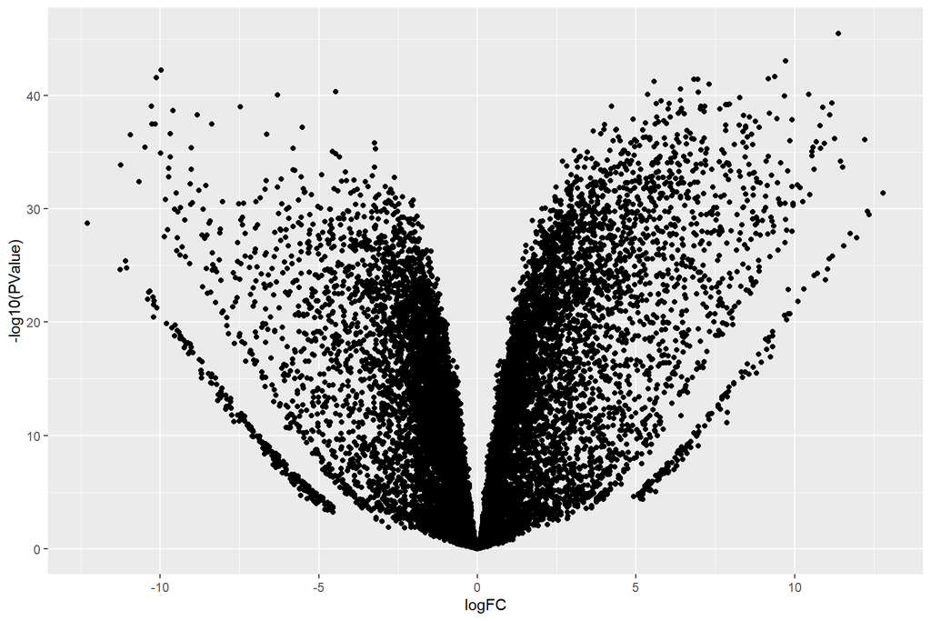

```r
complete_table <- as.data.frame(topTags(qlf,n=dim(dge)[1],adjust.method = 'BH'))
ggplot(data = complete_table,aes(x =logFC ,y = -log10(PValue)))+
  geom_point()
```